# GangEpl_Analysis_Update

Jimmy Zhang

9/7/2021

# An overview of the study design and variables in the GangEpl (Gang Employment) dataset:

This is a long form dataset in which each participant was measured multiple times (indicated by the variable Session). We have 337 observations and 57 variables in total.

Within-subject design: Youth were randomly assigned to either BEP or usual services (US), and data were collected at each intervention session. Hypothesis: Increases in employment among BEP participants would be related to reductions in gang involvement over the course of treatment.

Between-subject design: Compare BEP and US participants at the 3 month and 6 month assessment periods. Hypothesis: BEP would lead to higher employment and less gang involvement than US, and that changes in employment would mediate the effect of treatment on gang involvement.

Variables:

- ID -> Pariticipant ID
- Age -> The age of participant at each session
- Session -> Time point at which each participant was recorded
- Date -> The date is in year-month-date format (read in haven package)
- EmployHrs -> The hours of working in the current week
- EmployWg -> Hourly wage in the current week
- Del -> Participants’ report on the number of gang activities such as stealing over the previous week
- GangInv1 to GangInv4 -> Participants’ report on questions about the level of Gang Involvment
  - GangInv1 -> Days with Gang
  - GangInv2 -> Gang activity
- GangMem1 to GangMem15 -> Participants’ report on Gang Membership Inventory (the measure of gang membership)
- DC1 to DC12 -> Dummy coded variables for each participant (In the draft paper, the author stated that to identify sources of contamination expected from pooling data from multiple participants, a least squares with dummy variables (LSDV) approach was used. However, I really think a codebook is needed to address how these variables are dummy coded).

# Updates from Last Meeting

## Replicate the graphs in the original paper

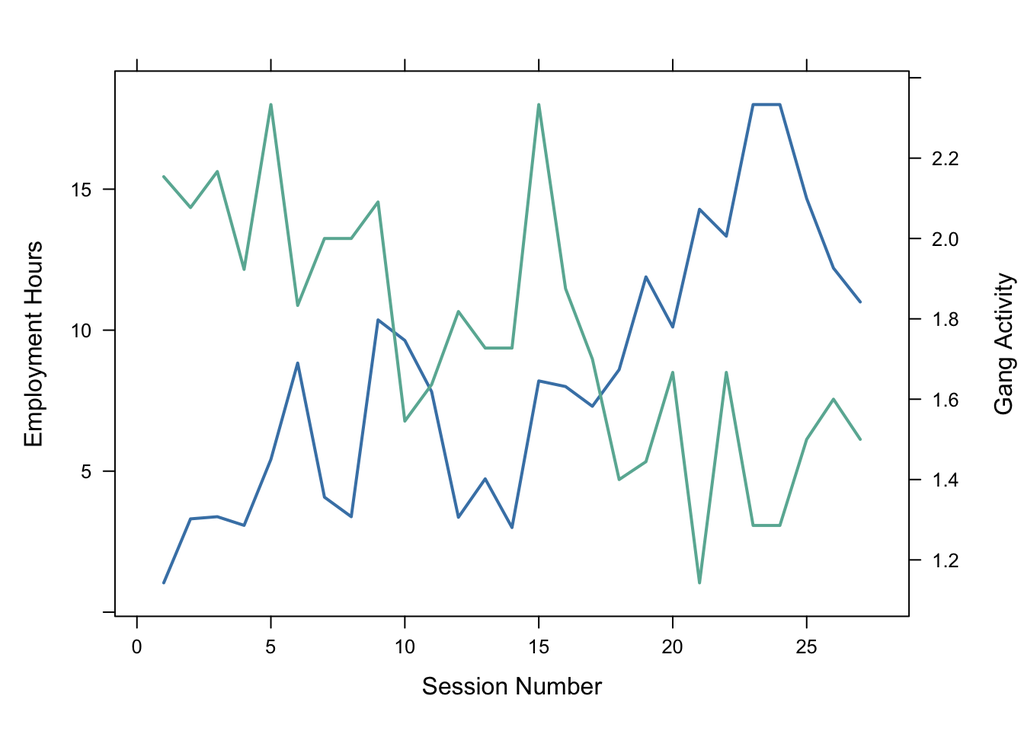

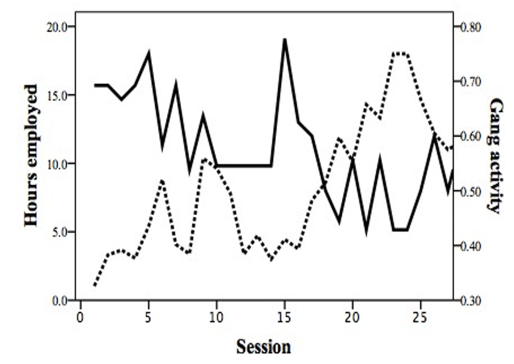

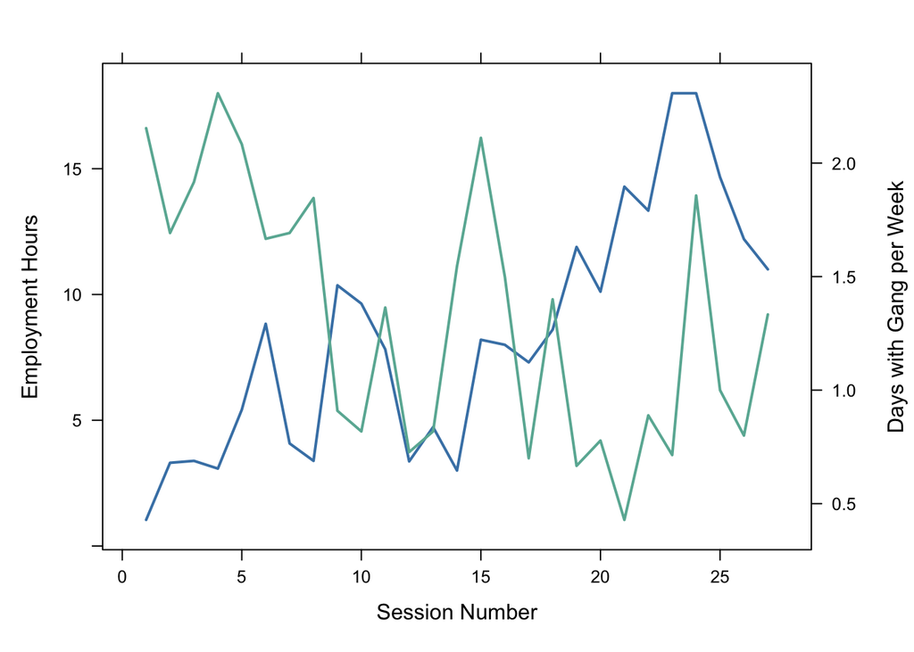

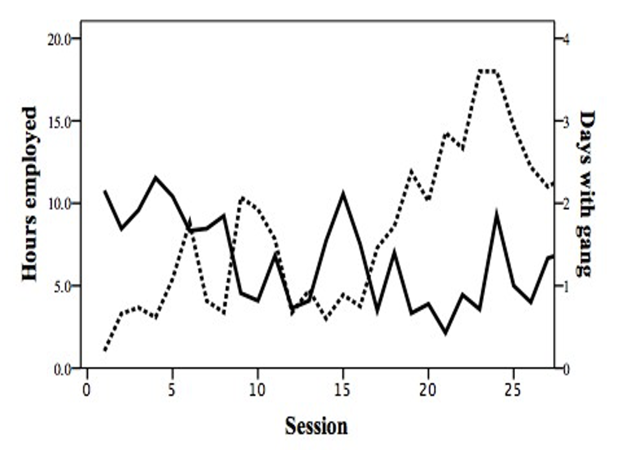

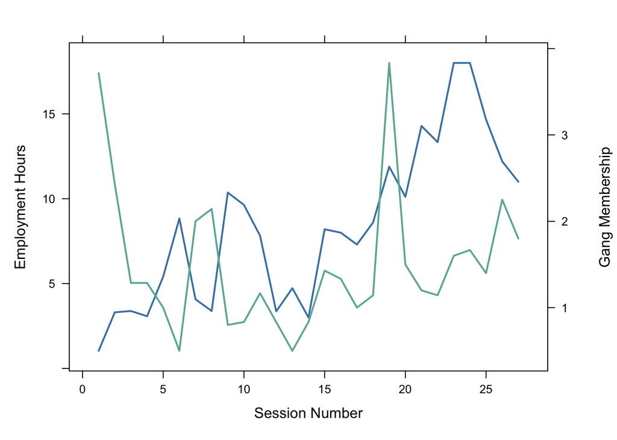

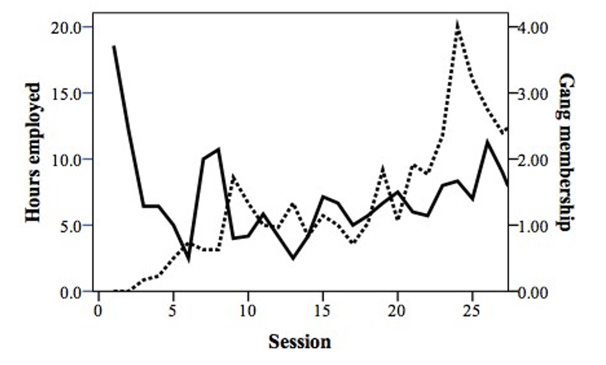

The plots I have replicated look roughly the same with the original plots, but they are still not exactly the same.

## MLM Analysis with Specified Data Range

The summary of MLM analysis from last time demonstrated that the independent variable `EmployHrs` (Employment Hours) did not significantly predict the dependent variables `Days_Gang` (Gang Involvement), `Gang_Mem` (Gang Membership), and `Gang_Activity` (Gang Activity). It seems that none of level1 and level2 variables of `EmployHrs` are significantly predicting the Gang Activity. However, the random effects of level2 variable (Centered Variable of `EmployHrs`) are significant.

Since the MLM analysis with all participants over all time ranges seems not satisfying (nearly no significant predictions by the IVs), one explanation could be that some participants did not have enough data of time points so their variations were not satisfying for MLM analysis. We excluded sessions longer than 6 months to ensure that the dataset had enough variations. Thus, we decided to block off those participants and re-do the analysis. Besides, since this is a longitudinal analysis, we think probably the lad predictors would also contribute to the variation of the DVs. Thus we will include lag predictors in the model.

| ID | EmployHrs | Gang_Activity | Days_Gang | GangMem |
| --- | --- | --- | --- | --- |
| 2 | 3.7142857 | 0.1428571 | 0.07142857 | NaN |
| 4 | 6.7857143 | 0.7380952 | 0.35714286 | NaN |
| 5 | 24.2291667 | 0.0000000 | 0.00000000 | 0.0000000 |
| 7 | 4.1428571 | 2.7142857 | 2.64285714 | 3.1818182 |
| 10 | 0.0000000 | 2.5555556 | 0.00000000 | NaN |
| 11 | 24.2352941 | 2.1176471 | 1.91176471 | 3.6250000 |
| 13 | 0.0000000 | 2.8500000 | 1.60000000 | 1.4761905 |
| 15 | 6.5384615 | 2.1538462 | 2.12820513 | 0.4615385 |
| 19 | 1.0000000 | 1.2727273 | 2.15151515 | 1.3636364 |
| 23 | 8.4146341 | 3.0000000 | 2.00000000 | 1.8536585 |

[output cut: 3 more lines]

### Gang Involvement

Here we can see the overall trend between Employ Hours and Gang Involvement is that for every average increase in centered employment hours the days with gangs of participants will decrease, although the decreasing trend looks not really obvious.

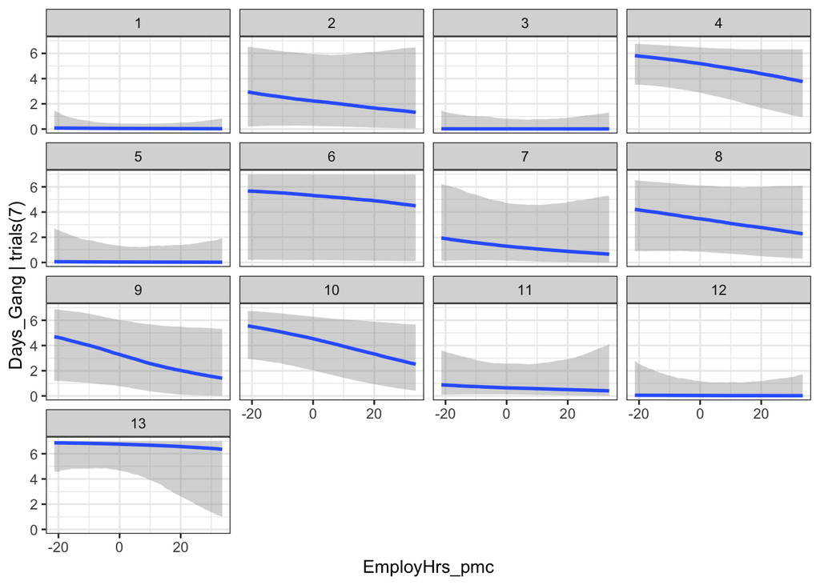

- Here are some plots of within-person conditional effects of covariates on Gang Involvement. The plot indicates that days spent with gang for each participant became averagely decreasing as the employment hours increase.

### Gang Activity

- The overall trend between Employ Hours and Gang Activity is that for every average increase in employment hours the days with gangs of participants will decrease, even though the trend looks not linear.
- Results of the model with covariate `Age` and `months`: It seems that Employment Hours is significant for Gang Activity at the within-person level, 95%CI [-0.16, -0.01]. Age is not a significant predictor. Month December with 95%CI [-9.44, -0.92], month January with 95%[-9.88, -0.29], and month November with 95%CI [-7.92,, -0.01], have been found significant for Gang Activity.
- Results of the model with lag predictor `EmployHrs_lag1`: It looks like the lag predictor of Employment Hour does not significantly predict Gang Activity.

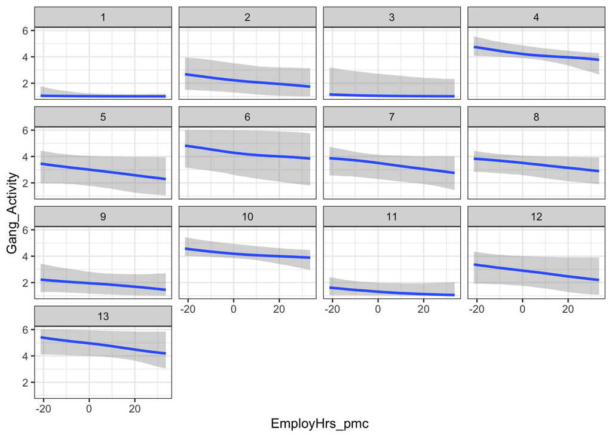

### Gang Membership

- Results of the binomial model with covariate `Age` and `months` (compute the probability of observing a specified number of “Successful Active Membership”): It seems that Employ Hours is not significant for Gang Membership at the within-person level, 95%CI [-0.07, 0.04]. Age is not a significant predictor for Gang Membership. Month August, December, July, November, October, and September have been found significant for Gang Membership.
- Results of the model with lag predictor `EmployHrs_lag1`: It looks like the lag predictor of Employment Hour does not significantly predict Gang Activity.

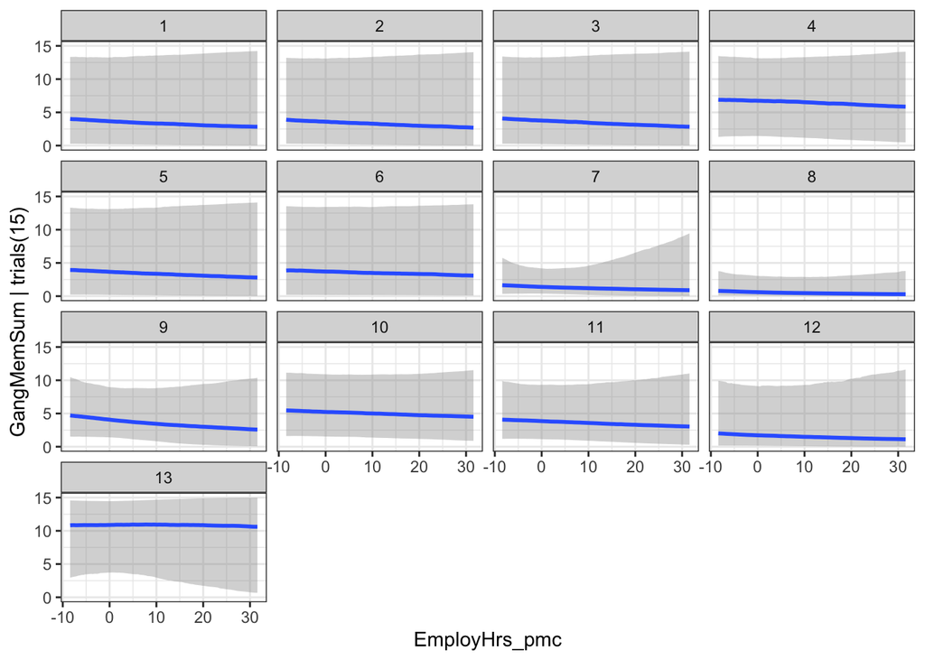

- The conditional effects of Employment Hours on Gang Membership looks really small because each line of within-person association is nearly close to horizontal.

## Coefficient Table

|  | Gang Involvement Binomial Model | Gang Membership Binomial Model | Gang Activity Gaussian Model |
| --- | --- | --- | --- |
| Fixed Effects |  |  |  |
| (Intercept) | −14.806 | −11.155 |  |
|  | [−31.179, 1.971] | [−26.502, 4.972] |  |
| Age | 0.787 | 0.541 | 1.022 |
|  | [−0.195, 1.752] | [−0.372, 1.445] | [−0.573, 3.034] |
| monthAugust | −1.212 | −1.992 | 0.057 |
|  | [−2.830, 0.384] | [−3.750, −0.280] | [−2.899, 2.861] |
| monthDecember | −3.959 | −2.770 | −4.389 |
|  | [−6.401, −1.653] | [−5.057, −0.614] | [−9.444, −0.917] |
| monthFebruary | −0.614 | 0.872 | −0.300 |
|  | [−2.107, 0.860] | [−0.370, 2.187] | [−3.090, 2.559] |
| monthJanuary | −1.171 | 1.423 | −4.493 |
|  | [−3.922, 1.418] | [−0.516, 3.362] | [−9.876, −0.290] |
| monthJuly | −1.106 | −2.393 | 1.433 |
|  | [−2.628, 0.347] | [−4.036, −0.828] | [−1.237, 4.374] |
| monthJune | −0.464 | −1.216 | −0.649 |
|  | [−1.882, 0.897] | [−2.801, 0.204] | [−3.414, 1.756] |
| monthMarch | −1.136 | −0.285 | −0.324 |
|  | [−2.603, 0.287] | [−1.764, 1.142] | [−2.857, 2.270] |
| monthMay | −0.307 | −1.249 | −0.397 |
|  | [−1.534, 0.865] | [−2.548, 0.025] | [−2.715, 1.685] |
| monthNovember | −2.271 | −2.180 | −3.297 |
|  | [−4.207, −0.337] | [−4.266, −0.328] | [−7.920, −0.009] |
| monthOctober | −1.892 | −2.063 | −2.730 |
|  | [−3.548, −0.196] | [−3.897, −0.352] | [−6.852, 0.082] |
| monthSeptember | −2.721 | −2.554 | −1.171 |
|  | [−4.382, −1.102] | [−4.339, −0.851] | [−4.500, 1.436] |
| EmployHrs_pm | −0.064 | 0.125 | −0.372 |
|  | [−0.371, 0.239] | [−0.063, 0.330] | [−0.994, 0.137] |
| EmployHrs_pmc | −0.024 | −0.013 | −0.078 |
|  | [−0.074, 0.018] | [−0.071, 0.041] | [−0.157, −0.009] |
| (Intercept)[1] |  |  | 8.790 |
|  |  |  | [−19.084, 41.153] |
| (Intercept)[2] |  |  | 13.309 |
|  |  |  | [−14.325, 46.610] |
| (Intercept)[3] |  |  | 16.545 |
|  |  |  | [−10.833, 50.431] |
| (Intercept)[4] |  |  | 22.478 |
|  |  |  | [−4.988, 57.710] |
| (Intercept)[5] |  |  | 26.255 |
|  |  |  | [−1.245, 61.694] |
| Random Effects |  |  |  |
| sd__(Intercept) | 3.596 | 1.700 | 6.743 |
|  | [2.105, 6.050] | [0.719, 3.480] | [3.900, 11.912] |
| sd__EmployHrs_pmc | 0.034 | 0.037 | 0.043 |
|  | [0.001, 0.113] | [0.001, 0.137] | [0.002, 0.133] |
| cor__(Intercept).EmployHrs_pmc | −0.104 | 0.169 | −0.213 |
|  | [−0.971, 0.936] | [−0.931, 0.972] | [−0.962, 0.866] |
| Num.Obs. | 271 | 176 | 271 |
| R2 |  |  | 0.804 |
| R2 Marg. |  |  | 0.245 |
| ELPD |  |  | −270.9 |
| ELPD s.e. |  |  | 25.6 |
| LOOIC | 870.2 | 638.7 | 541.7 |
| LOOIC s.e. |  |  | 51.3 |
| WAIC |  |  | 512.2 |
| algorithm | sampling | sampling |  |
| elpd_loo | −435.115 | −319.334 |  |
| p_loo | 176.777 | 120.152 |  |
| pss | 4000.000 | 4000.000 |  |

## Short Summary

We have some summary points for MLM analysis with covariates of month, age, and lag predictor of Employment Hours:

1. It looks like Employment Hours does have a within-person level (centered person-mean significant effects) only on Gang Activity. The general trends for three paired relationship (IV-DVs) are both slightly decreasing.
2. The covariate `Age` looks like not having significant effects on any of DVs, but some of `months` have significant effects on DVs, though the pattern of months is not clear to see.
3. The lag predictor of Employment Hours wasn’t found significantly predicting three DVs.